# Guided Lab: Applying different models

Let's look at the MNIST handwritten digits set and apply our machine learning techniques to this data set.

# [10] Overview of Dataset

```python
import matplotlib.pyplot as plt

from sklearn import datasets

# The digits dataset
digits = datasets.load_digits()
```

**Let's see what this data set is all about**

```python
print(digits['DESCR'])
```

```
.. _digits_dataset:

Optical recognition of handwritten digits dataset
--------------------------------------------------

**Data Set Characteristics:**

    :Number of Instances: 5620
    :Number of Attributes: 64
    :Attribute Information: 8x8 image of integer pixels in the range 0..16.
    :Missing Attribute Values: None
    :Creator: E. Alpaydin (alpaydin '@' boun.edu.tr)
    :Date: July; 1998

This is a copy of the test set of the UCI ML hand-written digits datasets
https://archive.ics.uci.edu/ml/datasets/Optical+Recognition+of+Handwritten+Digits

The data set contains images of hand-written digits: 10 classes where
each class refers to a digit.

Preprocessing programs made available by NIST were used to extract
normalized bitmaps of handwritten digits from a preprinted form. From a
total of 43 people, 30 contributed to the training set and different 13
to the test set. 32x32 bitmaps are divided into nonoverlapping blocks of
4x4 and the number of on pixels are counted in each block. This generates
an input matrix of 8x8 where each element is an integer in the range
0..16. This reduces dimensionality and gives invariance to small
distortions.

For info on NIST preprocessing routines, see M. D. Garris, J. L. Blue, G.
T. Candela, D. L. Dimmick, J. Geist, P. J. Grother, S. A. Janet, and C.
L. Wilson, NIST Form-Based Handprint Recognition System, NISTIR 5469,
1994.

.. topic:: References

  - C. Kaynak (1995) Methods of Combining Multiple Classifiers and Their
    Applications to Handwritten Digit Recognition, MSc Thesis, Institute of
    Graduate Studies in Science and Engineering, Bogazici University.
  - E. Alpaydin, C. Kaynak (1998) Cascading Classifiers, Kybernetika.
  - Ken Tang and Ponnuthurai N. Suganthan and Xi Yao and A. Kai Qin.
    Linear dimensionalityreduction using relevance weighted LDA. School of
    Electrical and Electronic Engineering Nanyang Technological University.
    2005.
  - Claudio Gentile. A New Approximate Maximal Margin Classification
    Algorithm. NIPS. 2000.
```

**Let's look at the different attributes on the `digits` object**

```python
digits.target
```

```
array([0, 1, 2, ..., 8, 9, 8])
```

```python
digits.data
```

```
array([[ 0.,  0.,  5., ...,  0.,  0.,  0.],
       [ 0.,  0.,  0., ..., 10.,  0.,  0.],
       [ 0.,  0.,  0., ..., 16.,  9.,  0.],
       ...,
       [ 0.,  0.,  1., ...,  6.,  0.,  0.],
       [ 0.,  0.,  2., ..., 12.,  0.,  0.],
       [ 0.,  0., 10., ..., 12.,  1.,  0.]])
```

**Let's see what these images look like.**

```python
digits.target[705]
```

```
3
```

```python
digits.images[705]
```

```
array([[ 0.,  0.,  6., 14., 16., 16.,  2.,  0.],
       [ 0.,  5., 16., 13., 11., 16.,  0.,  0.],
       [ 0.,  0.,  7.,  2., 15., 12.,  0.,  0.],
       [ 0.,  0.,  0.,  7., 16., 13.,  1.,  0.],
       [ 0.,  0.,  0.,  0.,  6., 15., 10.,  0.],
       [ 0.,  0.,  0.,  0.,  0., 15.,  9.,  0.],
       [ 0.,  0.,  3., 11.,  8., 16.,  6.,  0.],
       [ 0.,  0.,  7., 16., 16.,  8.,  0.,  0.]])
```

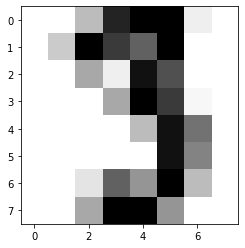

```python
plt.imshow(digits.images[705], cmap='Greys')
```

# [20] Exercise: Build a RandomForest

RandomForest is one of the most popular and powerful tools in the supervised machine learning toolkit.

## https://scikit-learn.org/stable/modules/generated/sklearn.ensemble.RandomForestClassifier.html

## Steps

1. Run Random Forest on the data.
2. Parameter Tuning (Number of Trees): Graph the accuracy of the Random Forest against the following 5 values of n_estimators: 5, 20, 100, 1000, 2000.
3. Which is the best for you?

# [20] Exercise: Build a LogisticRegression

Now build a logistic regression on the same dataset and see how it performs.

## https://scikit-learn.org/stable/modules/generated/sklearn.linear_model.LogisticRegression.html

## Steps

1. Graph the accuracy of the Logistic Regression against the following values of C: .001, .01, .1, 1, 10, 50.
2. Parameter Tuning: Choosing the optimal value of C, pass in the l1-norm regularization penalty penalty='l1' into the instantiation of the LogisticRegression(). How does the accuracy change?

# [20] Introduction to Neural Networks

## The Perception Model

Let's talk about the inputs, the weights and back-propagation at high-level

[figure not shown]

## Group Discussion/Thought Experiment Exercise

- Let's suppose we are creating a movie recommender service.
- We'll talk about online/offline learning and how the weights get updated based on "feedback to the model.

Suppose we have analyzed Amy's movie watching history and have come up with few inputs:

- x0: IMDB score
- x1: whether or not Edward Norton is in the film (0 or 1)
- x2: length of the movie

and the weights are as follows:

- w0: 7.5
- w1: 3
- w2: -3

### Questions

- How do we interpret these weights?
- What should happen to the weights if Amy watches a movie that is very LONG and she says she likes it?

## Let's Briefly Talk About Deep Learning

[figure not shown]

### Questions

1. What do the "hidden" layers do? How do we make sense of them?

# [20] Introduction to Reinforcement Learning

## Let's Explore RL Conceptually

### Terms

- state space
- action space
- penalty
- reward

Now, let's explore some RL applications.

## https://gym.openai.com/envs/#classic_control

# [10] VMWare Application of Reinforcement Learning

Let's talk about VMWare AI, which applies RL to managing your server infrastructure.

### Discussion

1. How would you apply the above framework to such a case?
2. What would be the action space? penalty? reward?